# Visualization in ggplot2 in Preparation for Case Study

Jason Bronowitz

23 June 2023

# Introduction

This code through explores how to use `ggplot2` to visualize data, using data available in R from the `gapminder` dataset. I encourage you to first try this code through using `gapminder` and then explore your own data using `ggplot2`.

**Prerequisite:** Before attempting this code through, be sure to complete DataCamp’s [Introduction to Data Visualization using ggplot2](https://app.datacamp.com/learn/courses/introduction-to-data-visualization-with-ggplot2).

If you enjoy visualization, I encourage you to continue on in DataCamp’s skill track, [Data Visualization with R](https://app.datacamp.com/learn/skill-tracks/data-visualization-with-r).

# Preparation

We’ve already loaded several relevant packages above, including `ggplot2` and `dplyr`, to facilitate data visualization. Next, let’s install and then load the `gapminder` dataset. Run the following chunk of code to install and learn about `gapminder`:

Learn more about the `gapminder` dataset here:  
https://cran.r-project.org/web/packages/gapminder/readme/README.html

```r
# Load required packages
install.packages("gapminder", repos = "http://cran.us.r-project.org")
library(gapminder)
```

# Methods of exploring your data

Explore the `gapminder` dataset with the goal of understanding each of its six variables. Here are three ways to do so. Think about when you might use each of these three ways.

```r
head(gapminder)
```

| country | continent | year | lifeExp | pop | gdpPercap |
| --- | --- | --- | --- | --- | --- |
| Afghanistan | Asia | 1952 | 28.801 | 8425333 | 779.4453 |
| Afghanistan | Asia | 1957 | 30.332 | 9240934 | 820.8530 |
| Afghanistan | Asia | 1962 | 31.997 | 10267083 | 853.1007 |
| Afghanistan | Asia | 1967 | 34.020 | 11537966 | 836.1971 |
| Afghanistan | Asia | 1972 | 36.088 | 13079460 | 739.9811 |
| Afghanistan | Asia | 1977 | 38.438 | 14880372 | 786.1134 |

```r
str(gapminder)
```

```
## tibble [1,704 × 6] (S3: tbl_df/tbl/data.frame)
##  $ country  : Factor w/ 142 levels "Afghanistan",..: 1 1 1 1 1 1 1 1 1 1 ...
##  $ continent: Factor w/ 5 levels "Africa","Americas",..: 3 3 3 3 3 3 3 3 3 3 ...
##  $ year     : int [1:1704] 1952 1957 1962 1967 1972 1977 1982 1987 1992 1997 ...
##  $ lifeExp  : num [1:1704] 28.8 30.3 32 34 36.1 ...
##  $ pop      : int [1:1704] 8425333 9240934 10267083 11537966 13079460 14880372 12881816 13867957 16317921 22227415 ...
##  $ gdpPercap: num [1:1704] 779 821 853 836 740 ...
```

```r
gapminder
```

| country | continent | year | lifeExp | pop | gdpPercap |
| --- | --- | --- | --- | --- | --- |
| Afghanistan | Asia | 1952 | 28.80100 | 8425333 | 779.4453 |
| Afghanistan | Asia | 1957 | 30.33200 | 9240934 | 820.8530 |
| Afghanistan | Asia | 1962 | 31.99700 | 10267083 | 853.1007 |
| Afghanistan | Asia | 1967 | 34.02000 | 11537966 | 836.1971 |
| Afghanistan | Asia | 1972 | 36.08800 | 13079460 | 739.9811 |
| Afghanistan | Asia | 1977 | 38.43800 | 14880372 | 786.1134 |
| Afghanistan | Asia | 1982 | 39.85400 | 12881816 | 978.0114 |
| Afghanistan | Asia | 1987 | 40.82200 | 13867957 | 852.3959 |
| Afghanistan | Asia | 1992 | 41.67400 | 16317921 | 649.3414 |
| Afghanistan | Asia | 1997 | 41.76300 | 22227415 | 635.3414 |

[output cut: 1694 more lines]

Write one sentence explaining, in your own words, what each of the three codes above accomplish:

- `head()`:
- `str()`:
- Running the name of the dataset:

## Summarizing median gdpPercap by continent

Run the following chunk of code to summarize median `gdpPercap` by `continent` in the `year` 1952. Then, adjust the code to re-run for 1997.

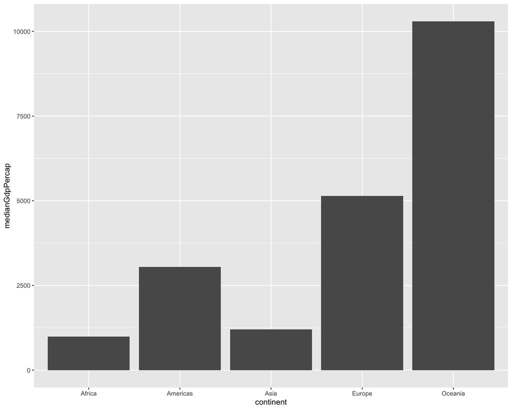

```r
# Summarize the median gdpPercap by continent in 1952
by_continent <- gapminder %>%
  filter(year == 1952) %>%
  group_by(continent) %>%
  summarize(medianGdpPercap = median(gdpPercap))

# Create a bar plot showing medianGdp by continent
ggplot(by_continent, aes(x = continent, y = medianGdpPercap)) +
  geom_col()
```

## Summarizing median lifeExp by country

Run the following chunk of code to summarize median `lifeExp` by `country`, limited to those countries in Oceania, in 2007. Then, adjust the code to re-run for the Americas (“`Americas`”) in 1987. Save this new `dplyr` filter as `by_country_americas` instead of `by_country_oceania`. Be sure to call the correct dataframe when plotting below.

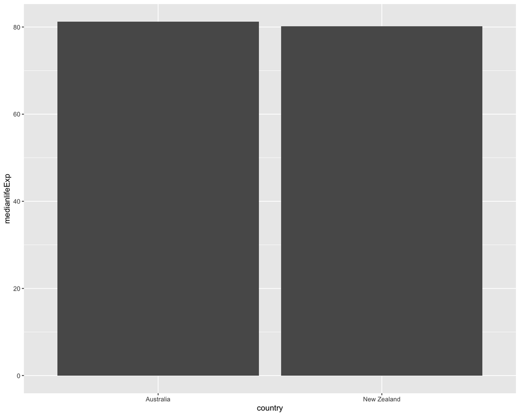

```r
# Summarize the median lifeExp by country, limited to those countries in Oceania, in 2007
by_country_oceania <- gapminder %>%
  filter(year == 2007, continent == "Oceania") %>%
  group_by(country) %>%
  summarize(medianlifeExp = median(lifeExp))

# Create a bar plot showing lifeExp by continent
ggplot(by_country_oceania, aes(x = country, y = medianlifeExp)) +
  geom_col()
```

# Recreate graphs using ggplot2

Replicate the following scatter plots as accurately as possible, using the `gapminder` dataset. For full credit, all elements must match, including the capitalization of “Continent”.

Consult for assistance: [Modify axis, legend, and plot labels](https://ggplot2.tidyverse.org/reference/labs.html)

## Graph #1

Open the image at the following URL: https://www.public.asu.edu/~jbronowi/Gapminder1.png

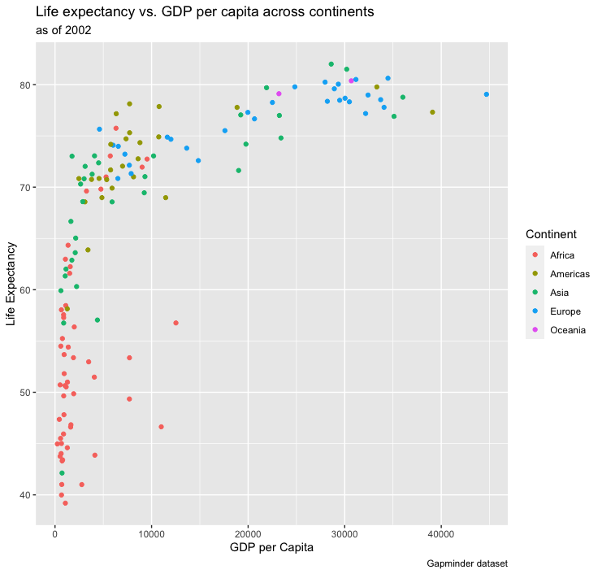

```r
# Recreate Graph #1 here
```

## Graph #2

Open the image at the following URL: https://www.public.asu.edu/~jbronowi/Gapminder2.png

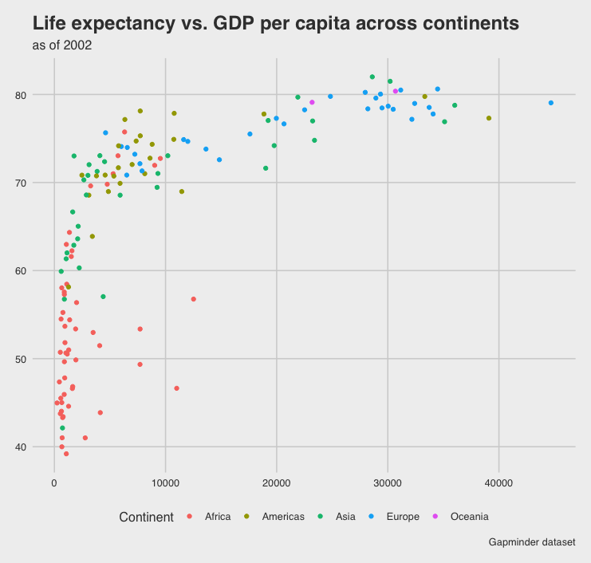

Hints for recreating Graph #2:

- With `ggthemes`, use `theme_fivethirtyeight()` but do not use its color scale
- Challenge: Explain why you can’t use `scale_color_fivethirtyeight()`

Additional resources:

- [ggthemes / fivethirtyeight](https://github.com/BTJ01/ggthemes/blob/master/inst/examples/ex-theme_fivethirtyeight.R)
- For more details (beyond this assignment): [Introduction to Data Science: ggplot2: Add On Packages](http://rafalab.dfci.harvard.edu/dsbook/ggplot2.html#add-on-packages)

```r
# Install required ggthtemes package and learn more using the ?ggthemes code.
install.packages('ggthemes', repos = "http://cran.us.r-project.org")
```

```r
library(ggthemes)
?ggthemes

# Recreate Graph #2 here
```

**Do not continue scrolling until you are ready to see the solutions.**

# Solutions

Here is my code for creating these two images:

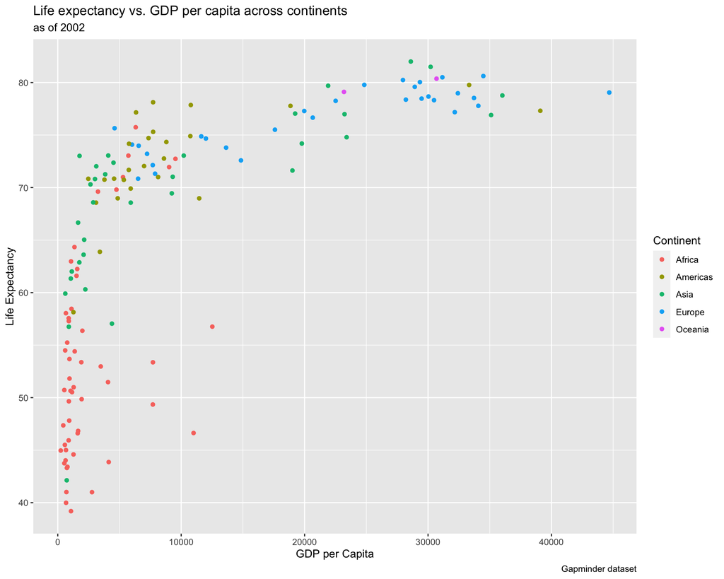

```r
# Graph 1
gapminder2002 <- gapminder %>%
  filter(year == 2002)
ggplot(gapminder2002, aes(x = gdpPercap, y = lifeExp, color = continent)) +
  geom_point() +
  ggtitle("Life expectancy vs. GDP per capita across continents") +
  labs(color = "Continent", subtitle = "as of 2002", caption = "Gapminder dataset") +
  xlab("GDP per Capita") +
  ylab("Life Expectancy")
```

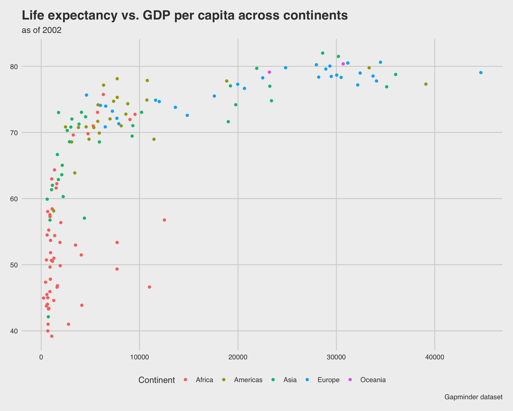

```r
# Graph 2
gapminder2002 <- gapminder %>%
  filter(year == 2002)
ggplot(gapminder2002, aes(x = gdpPercap, y = lifeExp, color = continent)) +
  geom_point() +
  ggtitle("Life expectancy vs. GDP per capita across continents") +
  labs(color = "Continent", subtitle = "as of 2002", caption = "Gapminder dataset") +
  theme_fivethirtyeight()
```

# How to Submit

Use the following instructions to submit your assignment, which may vary depending on your course’s platform. Thank you to Dr. Jesse Lecy for these instructions on submitting using `RMarkdown`.

### Knitting to HTML

When you have completed your assignment, click the “Knit” button to render your `.RMD` file into a `.HTML` report.

### Special Instructions

Perform the following depending on your course’s platform:

- **Canvas:** Upload both your `.RMD` and `.HTML` files to the appropriate link
- **Blackboard or iCollege:** Compress your `.RMD` and `.HTML` files in a `.ZIP` file and upload to the appropriate link

`.HTML` files are preferred but not allowed by all platforms.

### Before You Submit

Remember to ensure the following before submitting your assignment.

1. Name your files using this format: **Lab-##-LastName.rmd** and **Lab-##-LastName.html**
2. Show both the solution for your code and write out your answers in the body text
3. Do not show excessive output; truncate your output, e.g. with function `head()`
4. Follow appropriate styling conventions, e.g. spaces after commas, etc.
5. Above all, ensure that your conventions are consistent

See [Google’s R Style Guide](https://google.github.io/styleguide/Rguide.xml) for examples of common conventions.

### Common Knitting Issues

`.RMD` files are knit into `.HTML` and other formats procedural, or line-by-line.

- An error in code when knitting will halt the process; error messages will tell you the specific line with the error
- Certain functions like `install.packages()` or `setwd()` are bound to cause errors in knitting
- Altering a dataset or variable in one chunk will affect their use in all later chunks
- If an object is “not found”, make sure it was created or loaded with `library()` in a previous chunk

**If All Else Fails:** If you cannot determine and fix the errors in a code chunk that’s preventing you from knitting your document, add `eval = FALSE` inside the brackets of `{r}` at the beginning of a chunk to ensure that R does not attempt to evaluate it, that is: `{r eval = FALSE}`. This will prevent an erroneous chunk of code from halting the knitting process.

# Further Resources

Learn more about `ggplot2` with the following resources:

- Resource I [ggplot2: Elegant Graphics for Data Analysis](https://ggplot2-book.org/introduction.html)
- Resource II [R Graphics Cookbook](https://r-graphics.org/)
- Resource III [The Grammar of Graphics](https://ggplot2.tidyverse.org/)

# Works Cited

This code through references and cites the following sources:

- David Robinson, DataCamp. Source I. [Introduction to the Tidyverse: Types of Visualizations](https://campus.datacamp.com/courses/introduction-to-the-tidyverse/types-of-visualizations)
- Gapminder Dataset. Source II. [Download Dataset](https://assets.datacamp.com/production/repositories/1323/datasets/578a87c7d1e46b61ec2cfc0aaa1e42acb3d03a11/gapminder.tsv)
- Gapminder. Source III. [Gapminder](https://www.gapminder.org/)

# Acknowledgements

Thank you to Dr. Giovanni Circo and Dr. Jesse Lecy for inspiring this Code Through as part of ASU’s program in [Program Evaluation and Data Analytics](https://publicservice.asu.edu/masters-degrees-phds/majorinfo/PPPGEMS/graduate/false/2).